# MSDS-6371-Project Group 4

Ryan Herrin, Akib Hossain, Ronak Hamzehlou

4/6/2022

Import Data

```r
house_train_loc <- "data/starting_data/train.csv"
house_test_loc <- "data/starting_data/test.csv"

# Read in data
house_train <- read.csv(house_train_loc, header = TRUE)
house_test <- read.csv(house_test_loc, header = TRUE)
```

# Analysis Question 1

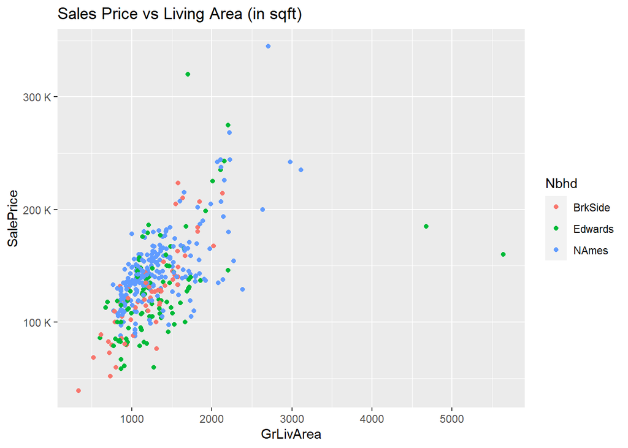

```r
# Create a data set that only includes the Neighborhoods, GrLIvArea, Salesprice
analys_1_data <- data.frame(Id=house_train$Id, Nbhd=house_train$Neighborhood,
                            GrLivArea=house_train$GrLivArea,
                            SalePrice=house_train$SalePrice)

# Narrow down the neighborhoods
analys_1_data <- filter(analys_1_data,
                        Nbhd == "NAmes" | Nbhd == "Edwards" | Nbhd == "BrkSide")

# Create a scatter plot to visualize the initial data
ggplot(analys_1_data, aes(x=GrLivArea, y=SalePrice, color=Nbhd)) +
  geom_point() +
  scale_y_continuous(labels = unit_format(unit = "K", scale = 1e-3)) +
  ggtitle("Sales Price vs Living Area (in sqft)")
```

- Edwards has a few outliers with high living areas space but a relatively average Sale price.
- Two noticable outliers in the Sales price

```r
# find Edwards outliers from original data set
# aq_1 = analysis question 1
aq_1_grlivarea_outliers <- filter(analys_1_data,
                                  Nbhd == "Edwards" & GrLivArea > 4000)
print(aq_1_grlivarea_outliers$Id)
```

```
## [1]  524 1299
```

```r
# Find outliers for sales price
aq_1_price_outliers <- filter(analys_1_data, SalePrice > 3e+05)
print(aq_1_price_outliers$Id)
```

```
## [1] 643 725
```

- This gives us ID 524, and 1299 for living area
- And 643 and 725 for sale price
- Need to keep an eye on the influence of these guys

Make seperate data frames for each Nhbd to reduce human errors from constantly filtering. Includes function to add or remove the outliers for the rest of the analysis 1 question. Always run this block before running lower blocks after a change is made.

```r
# Create function that removes or adds back in the outliers if needed

##############################################
# Set TRUE to include in data
# Set FALSE to exclude from data
use_price_outliers <- FALSE
use_grlivarea_outliers <- FALSE
##############################################

use_outlier <- function(data, bool_p, bool_la, p_outlrs, la_outlrs) {

  check_status <- function(data_tmp, x) {
    # Reusable to check if value is already in dataframe
    if (x %in% data_tmp$Id) {return(TRUE)} else {return(FALSE)}
  }#END

  # Logic to add price outlier in data frame
  if (bool_p == TRUE) {
    for (id in p_outlrs$Id) {
      if (check_status(data, id) == FALSE) {
        data = rbind(data, filter(p_outlrs, Id == id)) # Appends to df
  }}}

  # Logic to remove price outlier in data frame
  if (bool_p == FALSE) {
    for (id in p_outlrs$Id) {
      if (check_status(data, id) == TRUE) {
        data = data[!(data$Id == id),] # Remove from DF
  }}}

  # Logic to add living area outlier in data frame
  if (bool_la == TRUE) {
    for (id in la_outlrs$Id) {
      if (check_status(data, id) == FALSE) {
        data = rbind(data, filter(la_outlrs, Id == id)) # Appends to df
  }}}

  # Logic to remove living area outlier in data frame
  if (bool_la == FALSE) {
    for (id in la_outlrs$Id) {
      if (check_status(data, id) == TRUE) {
        data = data[!(data$Id == id),] # Remove from DF
  }}}

  return(data)
}

# Modifiy the dataframe to include or not include the outliers
analys_1_data <- use_outlier(analys_1_data, use_price_outliers,
                             use_grlivarea_outliers, aq_1_price_outliers,
                             aq_1_grlivarea_outliers)

# Make seperate data frames for each Nhbd
aq_1_NAmes <- filter(analys_1_data, Nbhd == "NAmes")
aq_1_Edwards <- filter(analys_1_data, Nbhd == "Edwards")
aq_1_BrkSide <- filter(analys_1_data, Nbhd == "BrkSide")

# Create fit models
aq_1_NAmes_fit <- lm(SalePrice ~ GrLivArea, data=aq_1_NAmes)
aq_1_Edwards_fit <- lm(SalePrice ~ GrLivArea, data=aq_1_Edwards)
aq_1_BrkSide_fit <- lm(SalePrice ~ GrLivArea, data=aq_1_BrkSide)
aq_1_all_nbhd_fit <- lm(SalePrice ~ GrLivArea, data=analys_1_data)
```

Add charts and add linear regression lines

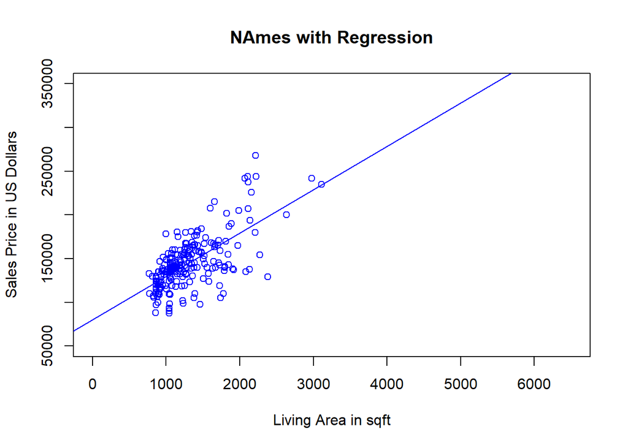

```r
# Create vars to set common scale for each plot
cust_y_lim <- c(50000, 350000)
cust_x_lim <- c(0, 6500)

# Linear regression plot for only NAmes
# Plot
plot(aq_1_NAmes$GrLivArea, aq_1_NAmes$SalePrice,
     xlab = "Living Area in sqft", ylab = "Sales Price in US Dollars",
     main= "NAmes with Regression", col = "blue",
     xlim = cust_x_lim, ylim = cust_y_lim)
abline(aq_1_NAmes_fit, col = "blue") # Add regression line
```

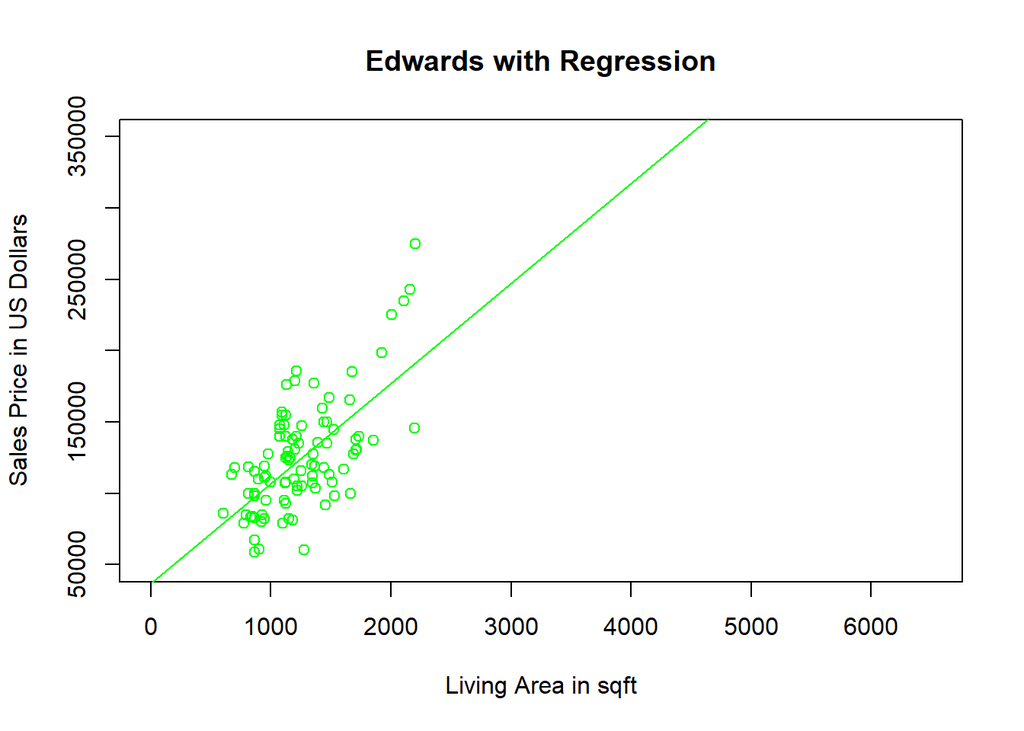

```r
# Linear regression plot for only Edwards
# Plot
plot(aq_1_Edwards$GrLivArea, aq_1_Edwards$SalePrice,
     xlab = "Living Area in sqft", ylab = "Sales Price in US Dollars",
     main= "Edwards with Regression", col = "green",
     xlim = cust_x_lim, ylim = cust_y_lim)
abline(aq_1_Edwards_fit, col = "green") # Add regression line
```

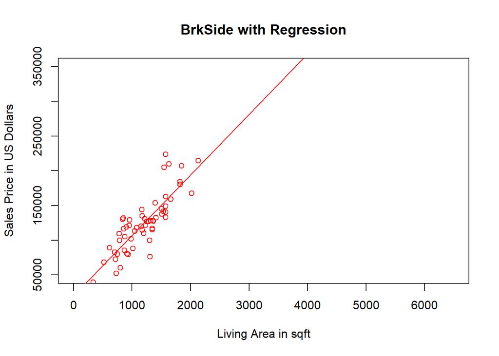

```r
# Linear regression plot for only BrkSide
# Plot
plot(aq_1_BrkSide$GrLivArea, aq_1_BrkSide$SalePrice,
     xlab = "Living Area in sqft", ylab = "Sales Price in US Dollars",
     main= "BrkSide with Regression", col = "red",
     xlim = cust_x_lim, ylim = cust_y_lim)
abline(aq_1_BrkSide_fit, col = "red") # Add regression line
```

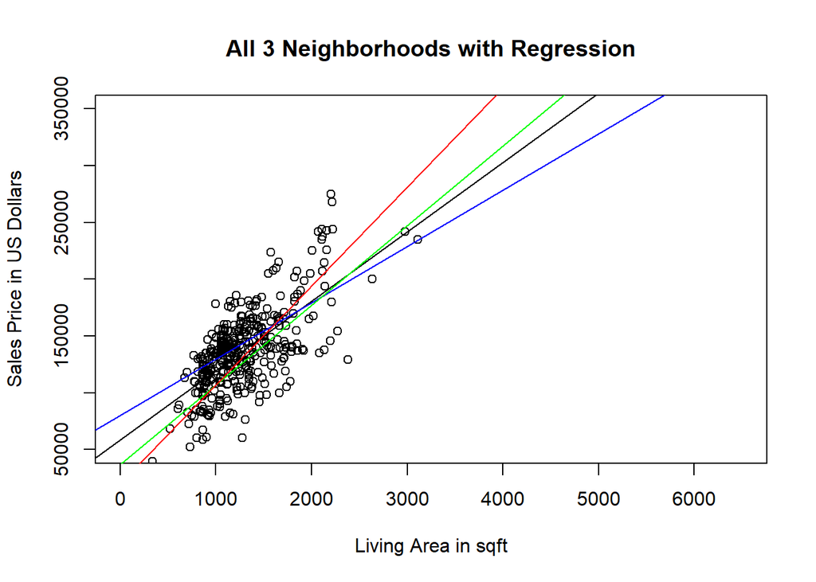

```r
# Create linear regression model with all locations included
# Plot
plot(analys_1_data$GrLivArea, analys_1_data$SalePrice,
     xlab = "Living Area in sqft", ylab = "Sales Price in US Dollars",
     main = "All 3 Neighborhoods with Regression",
     xlim = cust_x_lim, ylim = cust_y_lim)
abline(aq_1_all_nbhd_fit) # Add regression line for combines
abline(aq_1_NAmes_fit, col = "blue")
abline(aq_1_Edwards_fit, col = "green")
abline(aq_1_BrkSide_fit, col = "red")
```

- There is vidual evidence that the slopes are different for each neighborhood

Print out a summary of each fit model

```r
# Print Summary of fit models to find formula
# NAmes
summary(aq_1_NAmes_fit)
```

```
##
## Call:
## lm(formula = SalePrice ~ GrLivArea, data = aq_1_NAmes)
##
## Residuals:
##    Min     1Q Median     3Q    Max
## -69281 -11945   2824  13026  77797
##
## Coefficients:
##             Estimate Std. Error t value Pr(>|t|)
## (Intercept) 80325.71    5173.34   15.53   <2e-16 ***
## GrLivArea      49.56       3.79   13.08   <2e-16 ***
## ---
## Signif. codes:  0 '***' 0.001 '**' 0.01 '*' 0.05 '.' 0.1 ' ' 1
##
## Residual standard error: 22850 on 222 degrees of freedom
## Multiple R-squared:  0.4351, Adjusted R-squared:  0.4325
## F-statistic:   171 on 1 and 222 DF,  p-value: < 2.2e-16
```

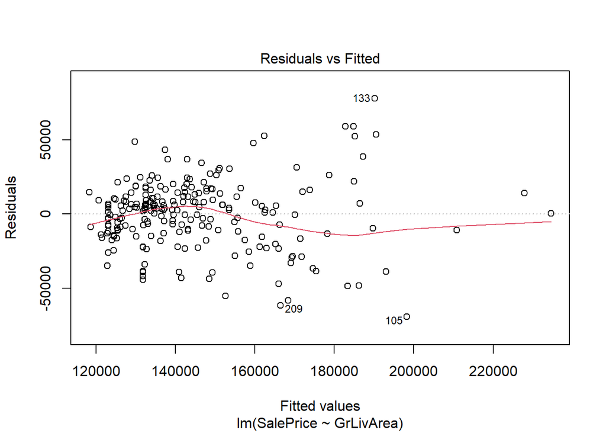

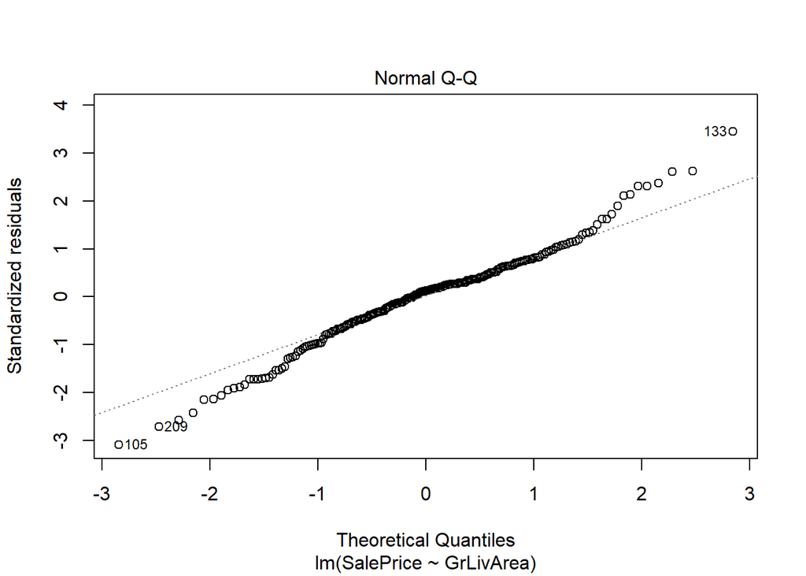

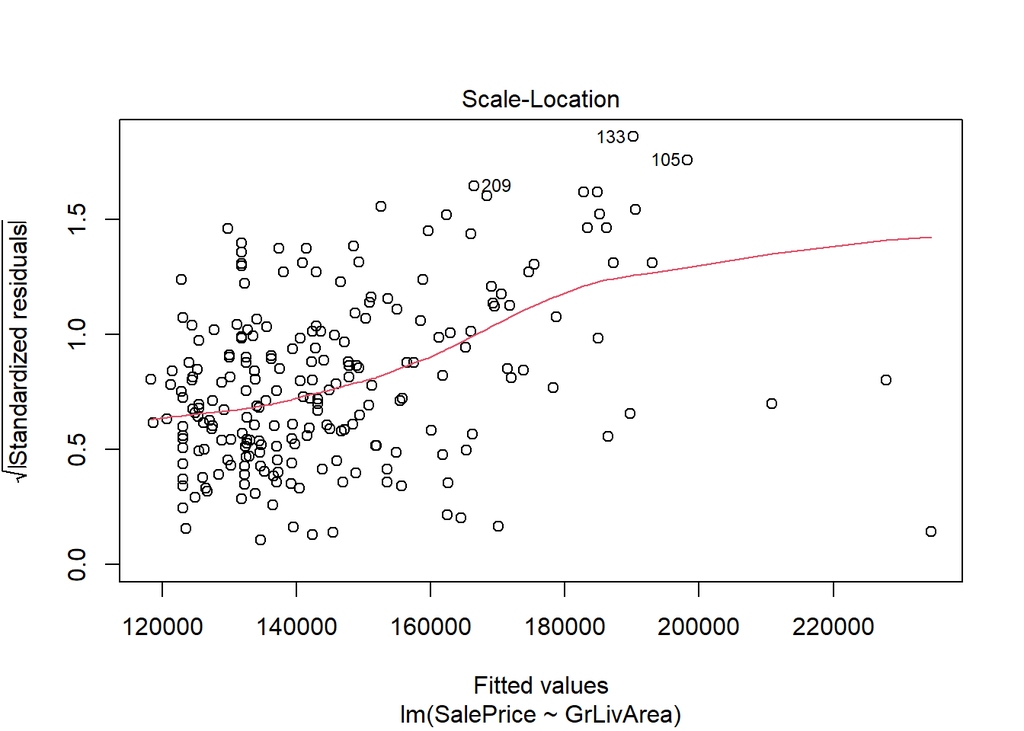

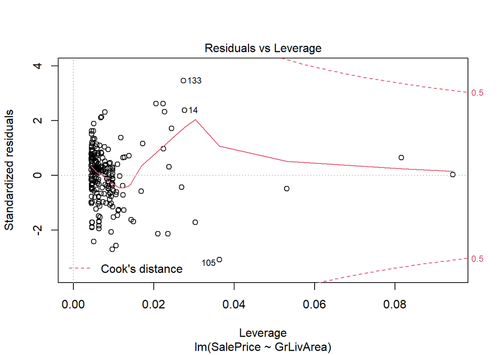

```r
plot(aq_1_NAmes_fit)
```

```r
# Edwards
summary(aq_1_Edwards_fit)
```

```
##
## Call:
## lm(formula = SalePrice ~ GrLivArea, data = aq_1_Edwards)
##
## Residuals:
##    Min     1Q Median     3Q    Max
## -66623 -21330    283  21644  83451
##
## Coefficients:
##              Estimate Std. Error t value Pr(>|t|)
## (Intercept) 37100.422  11148.404   3.328  0.00125 **
## GrLivArea      70.158      8.535   8.220 1.03e-12 ***
## ---
## Signif. codes:  0 '***' 0.001 '**' 0.01 '*' 0.05 '.' 0.1 ' ' 1
##
## Residual standard error: 29660 on 95 degrees of freedom
## Multiple R-squared:  0.4156, Adjusted R-squared:  0.4095
## F-statistic: 67.57 on 1 and 95 DF,  p-value: 1.033e-12
```

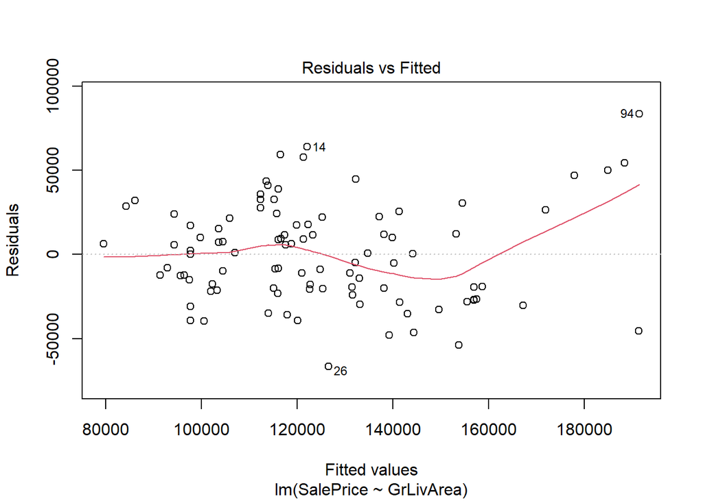

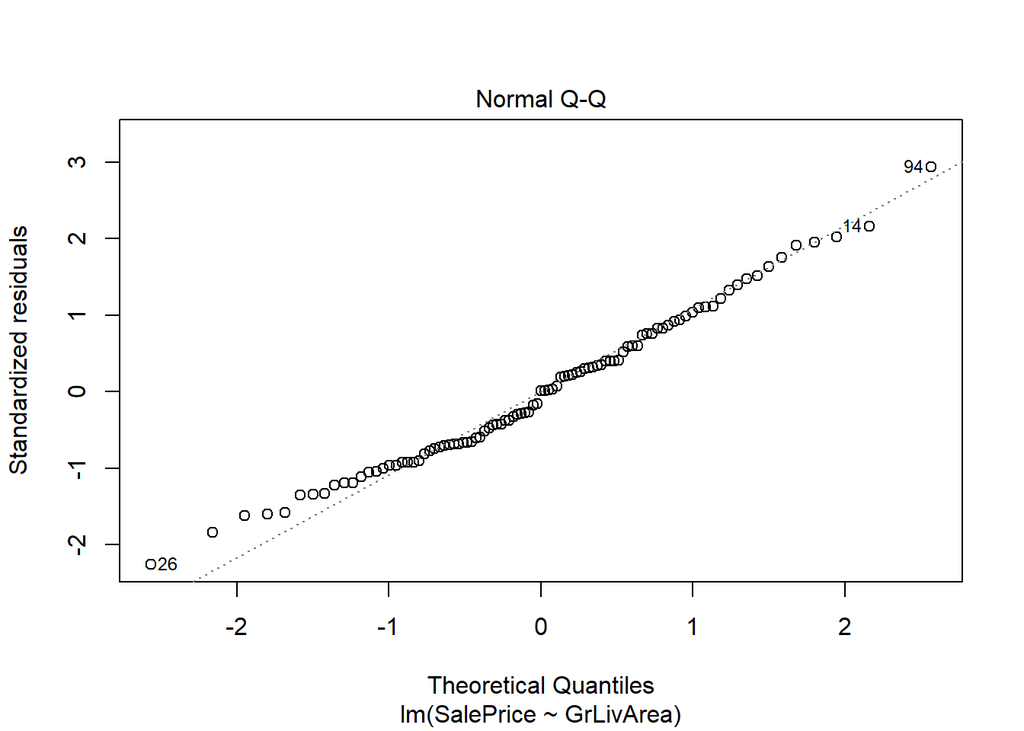

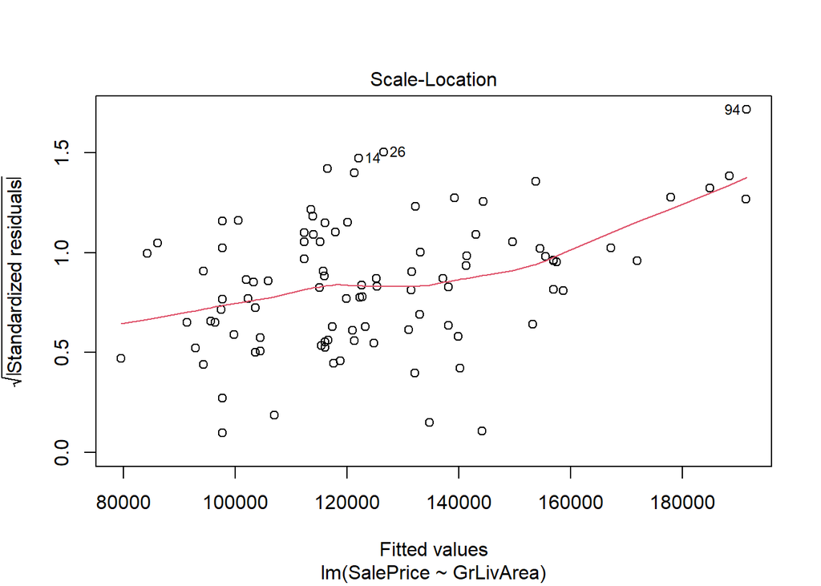

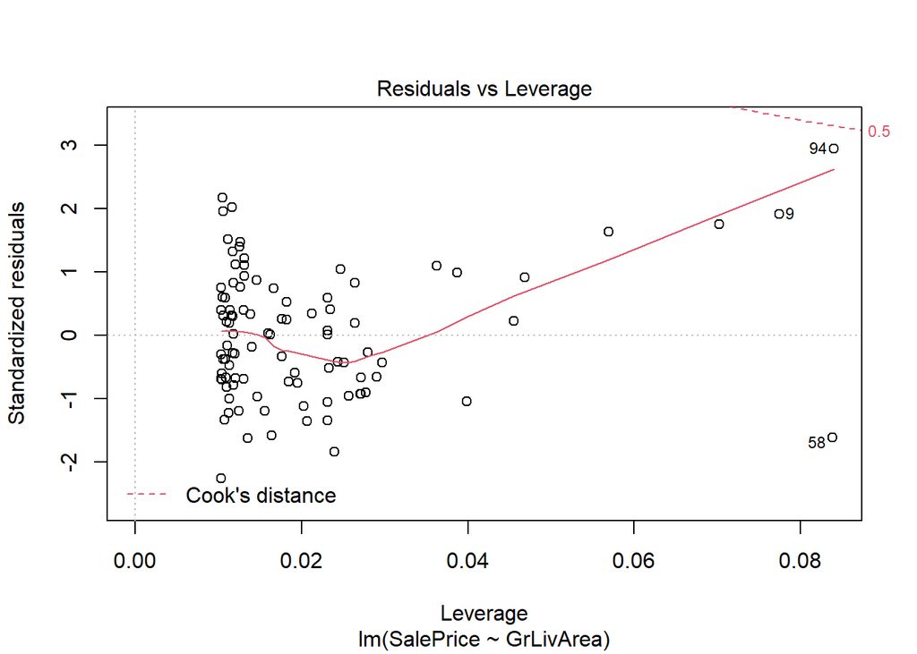

```r
plot(aq_1_Edwards_fit)
```

```r
# BrkSide
summary(aq_1_BrkSide_fit)
```

```
##
## Call:
## lm(formula = SalePrice ~ GrLivArea, data = aq_1_BrkSide)
##
## Residuals:
##    Min     1Q Median     3Q    Max
## -57306 -12367  -4445  11780  66160
##
## Coefficients:
##             Estimate Std. Error t value Pr(>|t|)
## (Intercept) 19971.51    9684.72   2.062   0.0438 *
## GrLivArea      87.16       7.67  11.364 3.63e-16 ***
## ---
## Signif. codes:  0 '***' 0.001 '**' 0.01 '*' 0.05 '.' 0.1 ' ' 1
##
## Residual standard error: 22390 on 56 degrees of freedom
## Multiple R-squared:  0.6975, Adjusted R-squared:  0.6921
## F-statistic: 129.1 on 1 and 56 DF,  p-value: 3.635e-16
```

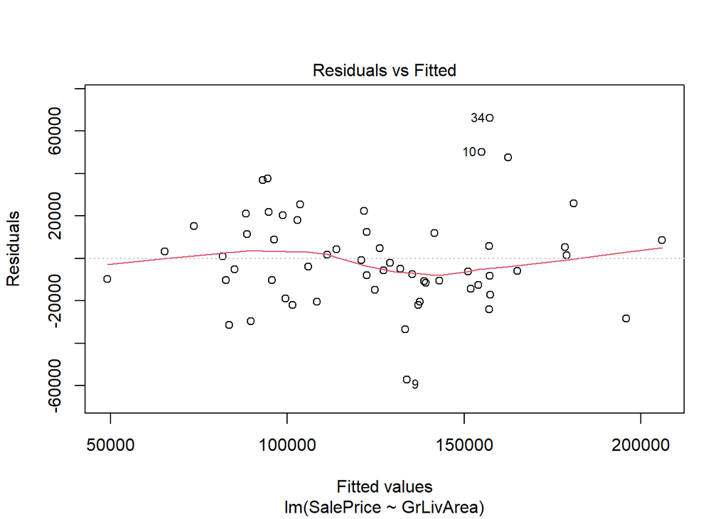

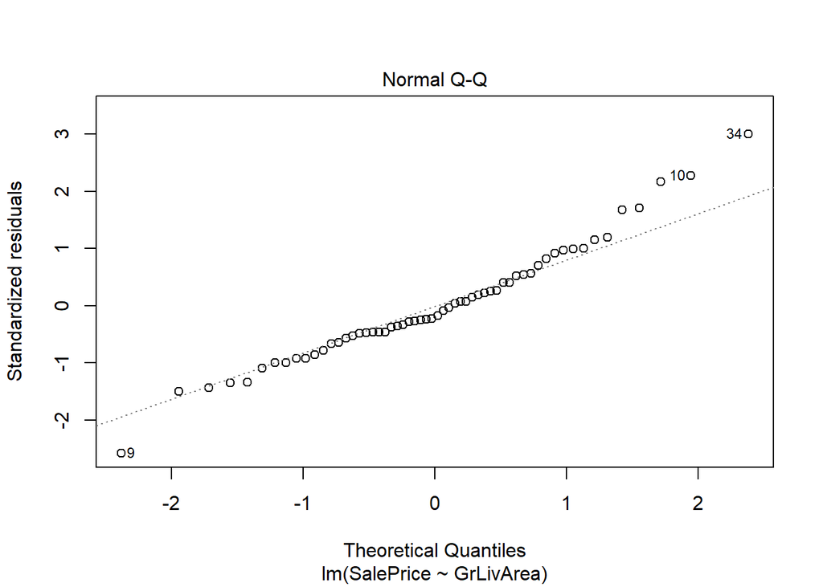

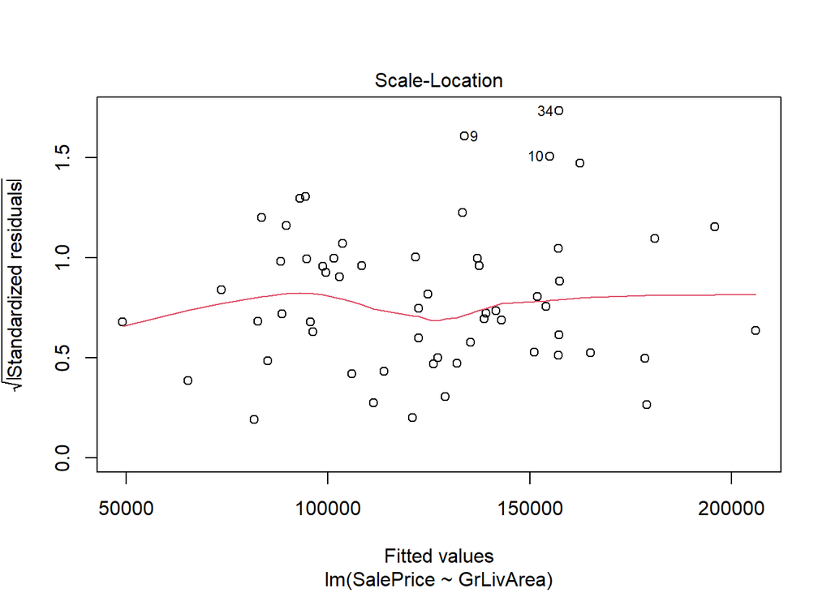

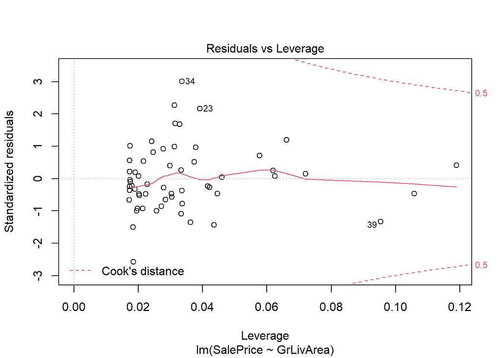

```r
plot(aq_1_BrkSide_fit)
```

```r
# All
summary(aq_1_all_nbhd_fit)
```

```
##
## Call:
## lm(formula = SalePrice ~ GrLivArea, data = analys_1_data)
##
## Residuals:
##    Min     1Q Median     3Q    Max
## -76811 -17774   2761  16603  81597
##
## Coefficients:
##              Estimate Std. Error t value Pr(>|t|)
## (Intercept) 58785.067   4643.194   12.66   <2e-16 ***
## GrLivArea      61.148      3.479   17.58   <2e-16 ***
## ---
## Signif. codes:  0 '***' 0.001 '**' 0.01 '*' 0.05 '.' 0.1 ' ' 1
##
## Residual standard error: 26370 on 377 degrees of freedom
## Multiple R-squared:  0.4504, Adjusted R-squared:  0.449
## F-statistic:   309 on 1 and 377 DF,  p-value: < 2.2e-16
```

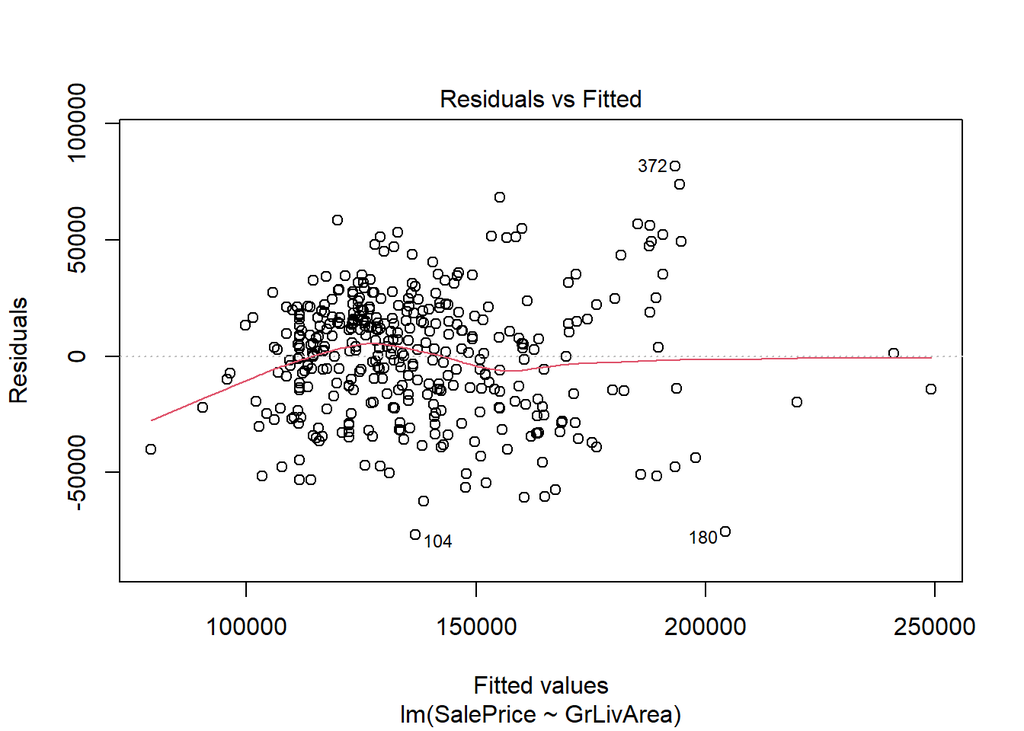

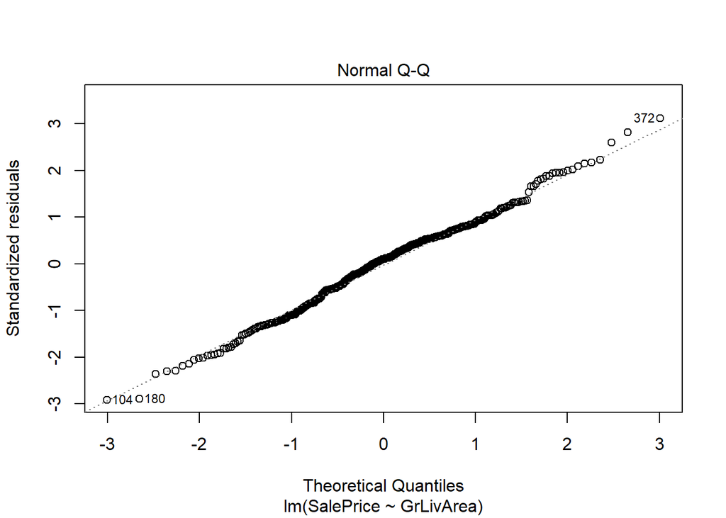

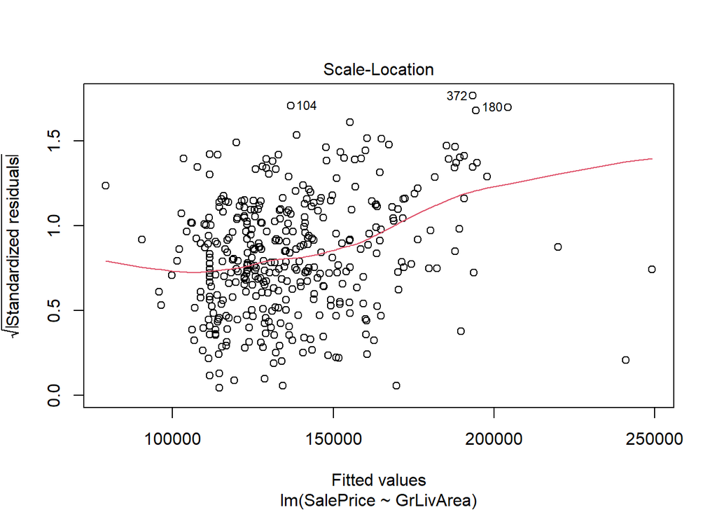

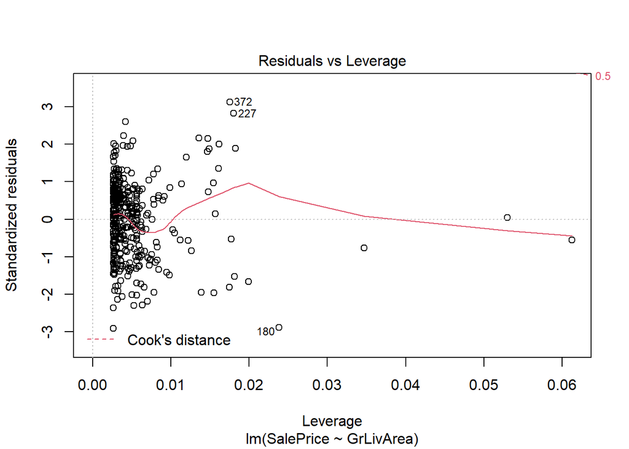

```r
plot(aq_1_all_nbhd_fit)
```

## Model Formulas

```r
# Create Sales Price for NAmes
NAmes_int <- round(aq_1_NAmes_fit[["coefficients"]][["(Intercept)"]],digits=2)
NAmes_slope <- round(aq_1_NAmes_fit[["coefficients"]][["GrLivArea"]],digits=2)

# Create Sales Price for Edwards
Edwards_int <- round(aq_1_Edwards_fit[["coefficients"]][["(Intercept)"]],digits=2)
Edwards_slope <- round(aq_1_Edwards_fit[["coefficients"]][["GrLivArea"]],digits=2)

# Create Sales Price for BrkSide
BrkSide_int <- round(aq_1_BrkSide_fit[["coefficients"]][["(Intercept)"]],digits=2)
BrkSide_slope <- round(aq_1_BrkSide_fit[["coefficients"]][["GrLivArea"]],digits=2)

cat(
"(SalesPrice | NAmes) = ", NAmes_int, " + ", NAmes_slope, "(Sqft)\n",
"(SalesPrice | Edwards) = ", Edwards_int, " + ", Edwards_slope, "(Sqft)\n",
"(SalesPrice | BrkSide) = ", BrkSide_int, " + ", BrkSide_slope, "(Sqft)\n",
sep = "")
```

```
## (SalesPrice | NAmes) = 80325.71 + 49.56(Sqft)
## (SalesPrice | Edwards) = 37100.42 + 70.16(Sqft)
## (SalesPrice | BrkSide) = 19971.51 + 87.16(Sqft)
```

```r
# Create confidence Intervals for the slopes
# NAmes Upper
NAmes_ci_upper <- aq_1_NAmes_fit[["coefficients"]][["GrLivArea"]] +
  (qt(.975, (nrow(aq_1_NAmes)-2)) * summary(aq_1_NAmes_fit)$coefficients[2,2])
NAmes_ci_upper <- round(NAmes_ci_upper, digits = 2) # Round off 2 spots
# NAmes Lower
NAmes_ci_lower <- aq_1_NAmes_fit[["coefficients"]][["GrLivArea"]] -
  (qt(.975, (nrow(aq_1_NAmes)-2)) * summary(aq_1_NAmes_fit)$coefficients[2,2])
NAmes_ci_lower <- round(NAmes_ci_lower, digits = 2) # Round off 2 spots

# Edwards Upper
Edwards_ci_upper <- aq_1_Edwards_fit[["coefficients"]][["GrLivArea"]] +
  (qt(.975, (nrow(aq_1_Edwards)-2)) * summary(aq_1_Edwards_fit)$coefficients[2,2])
Edwards_ci_upper <- round(Edwards_ci_upper, digits = 2) # Round off 2 spots
# Edwards Lower
Edwards_ci_lower <- aq_1_Edwards_fit[["coefficients"]][["GrLivArea"]] -
  (qt(.975, (nrow(aq_1_Edwards)-2)) * summary(aq_1_Edwards_fit)$coefficients[2,2])
Edwards_ci_lower <- round(Edwards_ci_lower, digits = 2) # Round off 2 spots

# BrkSide Upper
BrkSide_ci_upper <- aq_1_BrkSide_fit[["coefficients"]][["GrLivArea"]] +
  (qt(.975, (nrow(aq_1_BrkSide)-2)) * summary(aq_1_BrkSide_fit)$coefficients[2,2])
BrkSide_ci_upper <- round(BrkSide_ci_upper, digits = 2) # Round off 2 spots
# BrkSide Lower
BrkSide_ci_lower <- aq_1_BrkSide_fit[["coefficients"]][["GrLivArea"]] -
  (qt(.975, (nrow(aq_1_BrkSide)-2)) * summary(aq_1_BrkSide_fit)$coefficients[2,2])
BrkSide_ci_lower <- round(BrkSide_ci_lower, digits = 2) # Round off 2 spots

# Print out confidence intervals
cat(
'95% CI of NAmes [', NAmes_ci_lower, ', ', NAmes_ci_upper, ']\n',
'95% CI of Edwards [', Edwards_ci_lower, ', ', Edwards_ci_upper, ']\n',
'95% CI of BrkSide [', BrkSide_ci_lower, ', ', BrkSide_ci_upper, ']\n',
sep = "")
```

```
## 95% CI of NAmes [42.09, 57.03]
## 95% CI of Edwards [53.21, 87.1]
## 95% CI of BrkSide [71.8, 102.53]
```

# Analysis Question 2

```r
# Create a new DF that changes all chr columns into factors
aq_2_house_train <- house_train

# Change "chr" columns into "factor" columns
aq_2_house_train[sapply(aq_2_house_train, is.character)] <-
  lapply(aq_2_house_train[sapply(aq_2_house_train, is.character)], as.factor)

# Change "int" columns into "numeric" columns
aq_2_house_train[sapply(aq_2_house_train, is.integer)] <-
  lapply(aq_2_house_train[sapply(aq_2_house_train, is.integer)], as.numeric)

# Words cannot explain the pain it took to find out that these columns are the
# ones causing the linear fit model to fail.
aq_2_house_train <- subset(aq_2_house_train,
                           select = -c(Street, Alley, Utilities, PoolQC,
                                       MiscFeature, Condition2))

# Create Initial Model off original data set
# Remove Id variable
aq_2_init_model <- lm(SalePrice ~ . -Id, data = aq_2_house_train)
```

Okay lets narrow down the var selection by using the foward methed and setting an initial P-value of .2

```r
# Create the model to narrow down the selection
# Using the "olsrr" library
############################################################################
#ols_step_forward_p(aq_2_init_model, penter=0.2)
############################################################################
```

That took FOREVER to run…. I’m commenting it out so I don’t have to run it again Output is below:

## Selection Summary

[output not shown]

1 OverallQual 0.6257 0.6254 NaN 35659.4925 48622.7618  
2 GrLivArea 0.7142 0.7138 NaN 35267.5843 42501.3029  
3 Neighborhood 0.7868 0.7830 NaN 34887.2460 37008.5234  
4 BsmtQual 0.8078 0.8038 NaN 33861.2011 35163.0890  
5 RoofMatl 0.8269 0.8224 NaN 33726.7284 33459.8734  
6 BsmtFinSF1 0.8477 0.8436 NaN 33546.4954 31395.8751  
7 MSSubClass 0.8589 0.8550 NaN 33439.2811 30224.8066  
8 BsmtExposure 0.8684 0.8645 NaN 33323.5880 29230.4864  
9 KitchenQual 0.8768 0.8729 NaN 33235.6537 28311.5939  
10 OverallCond 0.8814 0.8775 NaN 33184.3985 27796.4746  
11 YearBuilt 0.8851 0.8813 NaN 33140.7575 27363.8972  
12 LotArea 0.8885 0.8847 NaN 33100.3303 26968.5175  
13 GarageCars 0.8906 0.8868 NaN 33075.2672 26722.8322  
14 PoolArea 0.8924 0.8886 NaN 33053.5060 26510.1530  
15 SaleCondition 0.8950 0.8908 NaN 33029.0629 26238.8848  
16 TotalBsmtSF 0.8963 0.8922 NaN 33012.5543 26078.2183  
17 Condition1 0.8986 0.8939 NaN 32996.8273 25864.7625  
18 Fireplaces 0.8996 0.8949 NaN 32985.3270 25751.7579  
19 ExterQual 0.9010 0.8961 NaN 32971.1178 25597.7283  
20 Functional 0.9026 0.8974 NaN 32959.4450 25441.9764  
21 LotConfig 0.9039 0.8984 NaN 32948.4802 25310.4650  
22 Exterior1st 0.9063 0.9000 NaN 32938.4776 25113.8290  
23 LandContour 0.9072 0.9007 NaN 32931.0707 25023.9359  
24 BldgType 0.9082 0.9015 NaN 32923.1147 24921.4947  
25 KitchenAbvGr 0.9086 0.9018 NaN 32919.5721 24882.3720  
26 LowQualFinSF 0.9090 0.9022 NaN 32915.8277 24841.5542  
27 YearRemodAdd 0.9093 0.9024 NaN 32912.5332 24804.7352  
28 LandSlope 0.9098 0.9028 NaN 32908.8634 24756.6784  
29 ScreenPorch 0.9101 0.9031 NaN 32905.9303 24723.1476  
30 MSZoning 0.9108 0.9036 NaN 32902.6114 24662.3992  
31 BedroomAbvGr 0.9111 0.9038 NaN 32899.5589 24627.9977  
32 TotRmsAbvGrd 0.9116 0.9043 NaN 32893.6229 24568.7282  
33 MasVnrArea 0.9117 0.9043 NaN 32704.8701 24523.6760  
34 BsmtFullBath 0.9119 0.9044 NaN 32703.3935 24502.9508  
35 GarageQual 0.9109 0.9026 NaN 31014.8491 24630.1265  
36 GarageCond 0.9115 0.9029 NaN 31014.2780 24591.6965  
37 WoodDeckSF 0.9117 0.9030 NaN 31013.3509 24574.9261  
38 MoSold 0.9119 0.9031 NaN 31012.6265 24560.0329  
39 X3SsnPorch 0.9120 0.9032 NaN 31012.4816 24550.4644  
40 GarageFinish 0.9123 0.9033 NaN 31012.3148 24532.4900  
41 MasVnrType 0.9126 0.9035 NaN 31013.1462 24515.5069  
42 Foundation 0.9131 0.9036 NaN 31014.3962 24494.2920  
43 LotFrontage 0.9177 0.9066 NaN 25468.2822 25412.9090  
44 FullBath 0.9179 0.9067 NaN 25467.1392 25389.6561  
45 LotShape 0.9184 0.9071 NaN 25466.0527 25347.1777  
46 X1stFlrSF 0.9186 0.9071 NaN 25468.0752 25337.5077  
47 X2ndFlrSF NA NA NA NA NA  
———————————————————————————

Alrighty. Lets create a new data set with only these guys

```r
# Create a new DF with the VARs from the first forward run
# Manually removing X1stFlrSF, X2ndFlrSF, and MoSold, RoofMatl, ScreenPorch
aq_2_train_reduced <- subset(aq_2_house_train,
  select = c(Id, OverallQual, GrLivArea, Neighborhood, BsmtQual,
             RoofMatl, BsmtFinSF1, MSSubClass, BsmtExposure, KitchenQual,
             OverallCond, YearBuilt, LotArea, GarageCars, PoolArea, SaleCondition,
             TotalBsmtSF, Condition1, Fireplaces, ExterQual, Functional, LotConfig,
             LandContour, BldgType, KitchenAbvGr, LowQualFinSF,
             YearRemodAdd, LandSlope, MSZoning, BedroomAbvGr,
             TotRmsAbvGrd, MasVnrArea, BsmtFullBath, GarageQual, GarageCond,
             WoodDeckSF, X3SsnPorch, GarageFinish, MasVnrType, Foundation,
             LotFrontage, FullBath, LotShape, SalePrice))
```

Split Data 80/20

```r
# Split the data 80/20 ##########
smp_size <- floor(0.80 * nrow(aq_2_train_reduced))
set.seed(123)
train_ind <- sample(seq_len(nrow(aq_2_train_reduced)), size = smp_size)
house_reduced_80 <- aq_2_train_reduced[train_ind, ]
house_reduced_20 <- aq_2_train_reduced[-train_ind, ]
#################################
```

```r
# Create another fit model
aq_2_reduced_model <- lm(SalePrice ~ . -Id, data = aq_2_train_reduced)
#summary(aq_2_reduced_model)
```

Now lets run that forward model again and see what it spits out

```r
# Use another redection to create the forward model
aq_2_forward <- ols_step_forward_p(aq_2_reduced_model, penter = .05)
aq_2_reduced_fwd_model <- aq_2_forward$model
```

Try to predict with the forward model

```r
# Makes a test to compare against the 80%
fwrd_results = data.frame(original=house_reduced_20$SalePrice,
                          est = predict(aq_2_reduced_fwd_model, house_reduced_20))
```

```r
fwrd_final <- data.frame(
  Id = house_test$Id,
  SalePrice = predict(aq_2_reduced_fwd_model, house_test)
)

write.csv(fwrd_final, "data/group4_Submission_fwd.csv", row.names = FALSE)
```

Kaggle Score of 0.18268

Backwards Model next

```r
# Create backwards model
aq_2_back <- ols_step_backward_p(aq_2_reduced_model, prem = .07)
aq_2_reduced_model_back <- aq_2_back$model

#summary(aq_2_reduced_model_back)

# Test against test data
back_results = data.frame(original=house_reduced_20$SalePrice,
                          est = predict(aq_2_reduced_model_back,
                                        house_reduced_20))
```

Create the stepwise model

```r
# Create a stepwise model
aq_2_step <- ols_step_both_p(aq_2_reduced_model, penter = 0.05, prem = .07)
aq_2_reduced_model_step <- aq_2_step$model

step_results = data.frame(original=house_reduced_20$SalePrice,
                          est = predict(aq_2_reduced_model_step,
                                        house_reduced_20))
```

Create output for the actual results to submit to kaggle

```r
step_final <- data.frame(
  Id = house_test$Id,
  SalePrice = predict(aq_2_reduced_model_step, house_test)
)

# Find and replace NA values
step_mean <- round(mean(step_final$SalePrice, na.rm = TRUE), digits = 2)
step_final$SalePrice[is.na(step_final$SalePrice)] <- step_mean

write.csv(step_final, "data/group4_Submission_step.csv", row.names = FALSE)
```

Kaggle Score: .20194